# ehlan_siddiqi_midterm

Ehlan Siddiqi

7/11/2018

```r
library(tidyverse)
library(ggplot2)
```

[GitHub - Click here!](https://github.com/ehlan/compscix-415-2-assignments)

## Midterm Examination - Ehlan Siddiqi

### Table of Content (click to jump to each section)

1. RStudio and R Markdown  
2. The tidyverse packages  
3. R Basics  
4. Data import/export  
5. Visualization  
6. Data munging and wrangling  
7. EDA  
8. GIT and Github

## 1. RStudio and R Markdown

- Provided

## 2. The tidyverse packages

**1. Can you name which package is associated with each task below?**

**Plotting -** ggplot2

**Data munging/wrangling -** dplyr

**Reshaping (speading and gathering) data -** tidyr, tibble

**Importing/exporting data -** readr

**2. Now can you name two functions that you’ve used form each package that you listed above for these tasks?**

**Plotting -**geom_boxplot(), geom_point().

**Data munging/wrangling** - mutate(), select().

**Reshaping (speading and gathering) data -** spread(), gather().

**Importing/exporting data -** read_delim(), read_csv().

## 3. R Basics

**1. Fix this code with fewest number of changes possible to it works:**

```r
My_data.name___is.too00ooLong <- c( 1 , 2   , 3 )
```

**2. Fix this code so it works:**

```r
my_string <- c('has', 'an', 'error', 'in', 'it')
```

**3. Look at the code below and comment on what happened to the values in the vector:** my_vector <- c(1, 2, ‘3’, ‘4’, 5) my_vector

Answer: They all got converted to String because of c() method.

## 4. Data import/export

**1. Download the rail_trail.txt file from Canvas (in the Midterm Exam section) and successfully import it into R. Prove that it was imported successfully by including your import code and taking a glimpse of the result.**

```r
file_path <- '/Users/ehlansiddiqi/Downloads/rail_trail.txt'
rail_trail_data <- read_delim(file_path, delim = '|')
glimpse(rail_trail_data)
```

```
## Observations: 90
## Variables: 10
## $ hightemp   <int> 83, 73, 74, 95, 44, 69, 66, 66, 80, 79, 78, 65, 41,...
## $ lowtemp    <int> 50, 49, 52, 61, 52, 54, 39, 38, 55, 45, 55, 48, 49,...
## $ avgtemp    <dbl> 66.5, 61.0, 63.0, 78.0, 48.0, 61.5, 52.5, 52.0, 67....
## $ spring     <int> 0, 0, 1, 0, 1, 1, 1, 1, 0, 0, 0, 1, 1, 0, 0, 1, 0, ...
## $ summer     <int> 1, 1, 0, 1, 0, 0, 0, 0, 1, 1, 1, 0, 0, 0, 0, 0, 1, ...
## $ fall       <int> 0, 0, 0, 0, 0, 0, 0, 0, 0, 0, 0, 0, 0, 1, 1, 0, 0, ...
## $ cloudcover <dbl> 7.6, 6.3, 7.5, 2.6, 10.0, 6.6, 2.4, 0.0, 3.8, 4.1, ...
## $ precip     <dbl> 0.00, 0.29, 0.32, 0.00, 0.14, 0.02, 0.00, 0.00, 0.0...
## $ volume     <int> 501, 419, 397, 385, 200, 375, 417, 629, 533, 547, 4...
## $ weekday    <int> 1, 1, 1, 0, 1, 1, 1, 0, 0, 1, 1, 1, 1, 1, 1, 1, 0, ...
```

**2. Export the file into a comma-separated file and name it “rail_trail.csv”. Make sure you define the path correctly so that you know where it gets saved. Then reload the file. Include your export and import code and take another glimpse.**

```r
write_csv(rail_trail_data, '/Users/ehlansiddiqi/Downloads/rail_trail.csv')
rail_trail_csv <- read_csv('/Users/ehlansiddiqi/Downloads/rail_trail.csv')
glimpse(rail_trail_csv)
```

```
## Observations: 90
## Variables: 10
## $ hightemp   <int> 83, 73, 74, 95, 44, 69, 66, 66, 80, 79, 78, 65, 41,...
## $ lowtemp    <int> 50, 49, 52, 61, 52, 54, 39, 38, 55, 45, 55, 48, 49,...
## $ avgtemp    <dbl> 66.5, 61.0, 63.0, 78.0, 48.0, 61.5, 52.5, 52.0, 67....
## $ spring     <int> 0, 0, 1, 0, 1, 1, 1, 1, 0, 0, 0, 1, 1, 0, 0, 1, 0, ...
## $ summer     <int> 1, 1, 0, 1, 0, 0, 0, 0, 1, 1, 1, 0, 0, 0, 0, 0, 1, ...
## $ fall       <int> 0, 0, 0, 0, 0, 0, 0, 0, 0, 0, 0, 0, 0, 1, 1, 0, 0, ...
## $ cloudcover <dbl> 7.6, 6.3, 7.5, 2.6, 10.0, 6.6, 2.4, 0.0, 3.8, 4.1, ...
## $ precip     <dbl> 0.00, 0.29, 0.32, 0.00, 0.14, 0.02, 0.00, 0.00, 0.0...
## $ volume     <int> 501, 419, 397, 385, 200, 375, 417, 629, 533, 547, 4...
## $ weekday    <int> 1, 1, 1, 0, 1, 1, 1, 0, 0, 1, 1, 1, 1, 1, 1, 1, 0, ...
```

## 5. Visualization

- I would use MADAM PRESIDENT and bold both words.
- This is not tidy. Age range and gender are used in the same line. Although used different color, but it does not give a clear visual. The circular shapes are also not to proportion and they are overwhelming be bigger than the graph header (yes/no).
- Major flaw in this chart is that it does not specify how many Men and Women within the age range given has provided the answer. A simplified histogram with y axis being age range and Men Women in parrellel bar would make it more effective.

**2. Reproduce this graphic using the diamonds data set.**

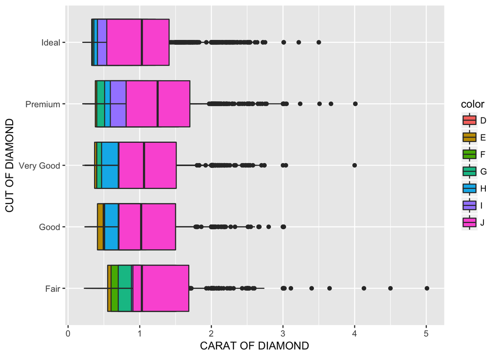

```r
ggplot(data = diamonds) +
  geom_boxplot(aes(x = cut, y= carat, fill = color), position = 'identity')+
  xlab('CUT OF DIAMOND')+
  ylab('CARAT OF DIAMOND')+
  coord_flip()
```

**3. The previous graphic is not very useful. We can make it much more useful by changing one thing about it. Make the change and plot it again.**

The graph was not showing carats for each color. It had an overlap. Replacing the identity will fix it.

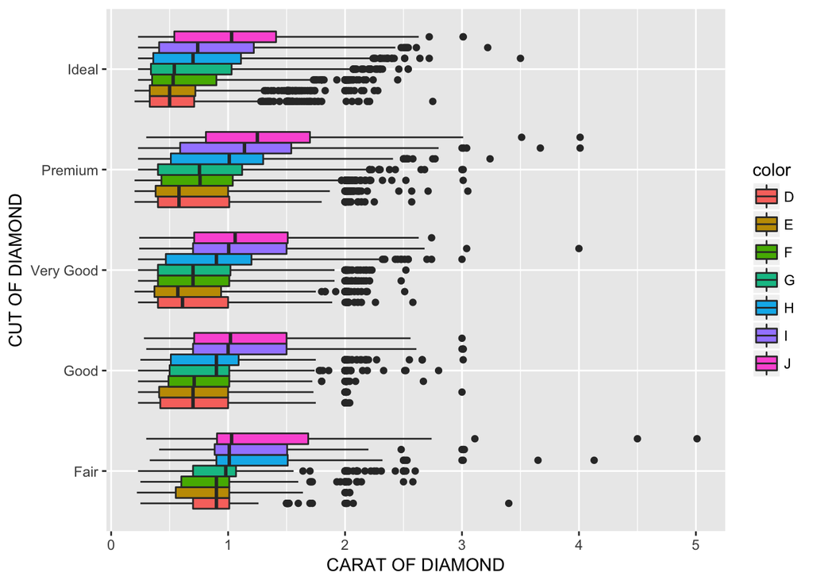

```r
ggplot(data = diamonds) +
  geom_boxplot(aes(x = cut, y= carat, fill = color), position = 'dodge')+
  xlab('CUT OF DIAMOND')+
  ylab('CARAT OF DIAMOND')+
  coord_flip()
```

## 6. Data munging and wrangling

**1. Is this data “tidy”? If yes, leave it alone and go to the next problem. If no, make it tidy. Note: this data set is called table2 and is available in the tidyverse package. It should be ready for you to use after you’ve loaded the tidyverse package.**

This data is not tidy because the ‘type’ and ‘count’ column contains only key of the count value. This can be made tidy using the spread() method

```r
spread(table2, type, count)
```

```
## # A tibble: 6 x 4
##   country      year  cases population
##   <chr>       <int>  <int>      <int>
## 1 Afghanistan  1999    745   19987071
## 2 Afghanistan  2000   2666   20595360
## 3 Brazil       1999  37737  172006362
## 4 Brazil       2000  80488  174504898
## 5 China        1999 212258 1272915272
## 6 China        2000 213766 1280428583
```

**2. Create a new column in the diamonds data set called price_per_carat that shows the price of each diamond per carat (hint: divide). Only show me the code, not the output.**

```r
diamonds$price_per_carat <- (diamonds$price / diamonds$carat)
```

**3. For each cut of diamond in the diamonds data set, how many diamonds, and what proportion, have a price > 10000 and a carat < 1.5? There are several ways to get to an answer, but your solution must use the data wrangling verbs from the tidyverse in order to get credit.**

```r
result <- diamonds %>%
  filter(price > 10000, carat < 1.5)
result
```

```
## # A tibble: 834 x 11
##    carat cut       color clarity depth table price     x     y     z
##    <dbl> <ord>     <ord> <ord>   <dbl> <dbl> <int> <dbl> <dbl> <dbl>
##  1  1.03 Ideal     E     VVS2     60.6    59 10003  6.5   6.53  3.95
##  2  1.23 Very Good G     VVS2     60.6    55 10004  6.93  7.02  4.23
##  3  1.25 Ideal     F     VS2      61.6    55 10006  6.93  6.96  4.28
##  4  1.21 Very Good F     VS1      62.3    58 10009  6.76  6.85  4.24
##  5  1.01 Fair      D     SI2      64.6    58 10011  6.25  6.2   4.02
##  6  1.05 Ideal     F     VVS2     60.5    55 10011  6.67  6.58  4.01
##  7  1.35 Premium   G     VS1      62.1    59 10012  7.06  7.02  4.37
##  8  1.13 Ideal     F     VS1      60.9    57 10016  6.73  6.76  4.11
##  9  1.21 Premium   F     VS1      62.6    59 10018  6.81  6.76  4.25
## 10  1.01 Very Good F     VVS1     62.9    57 10019  6.35  6.41  4.01
## # ... with 824 more rows, and 1 more variable: price_per_carat <dbl>
```

**Do the results make sense? Why?**

```
No.The prices seems inconsistent with the qulity of the dimaonds. A lesser carat and cut seems to have higher price.
```

**Do we need to be wary of any of these numbers? Why?**

```
Higher carat and cut should lead to higer price. So these numbers may not be accurate.
```

## 7. EDA

**Take a look at the txhousing data set that is included with the ggplot2 package and answer these questions:**

**1. During what time period is this data from?**

```r
min(txhousing$year, na.rm=T)
```

```
## [1] 2000
```

```r
max(txhousing$year, na.rm=T)
```

```
## [1] 2015
```

This is from the year 2000 to 2015

**2. How many cities are represented?**

```r
sum(!duplicated(txhousing$city))
```

```
## [1] 46
```

46

**3. Which city, month and year had the highest number of sales?**

```r
answer <- txhousing %>% filter(sales == max(txhousing$sales, na.rm=T))
glimpse(answer$city)
```

```
##  chr "Houston"
```

**4. What kind of relationship do you think exists between the number of listings and the number of sales? Check your assumption and show your work.**

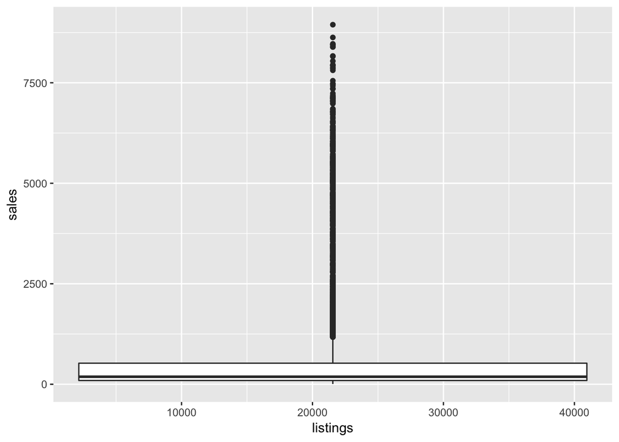

```r
ggplot(data = txhousing, mapping = aes(x = listings, y = sales))+
  geom_boxplot()
```

**5. What proportion of sales is missing for each city?**

```r
sum(is.na(txhousing$sales))
```

```
## [1] 568
```

```r
sum(!is.na(txhousing$sales))
```

```
## [1] 8034
```

```r
aggregate(txhousing$sales, by= list(city = txhousing$city), FUN=sum, na.rm = TRUE)
```

```
##                     city       x
## 1                Abilene   28141
## 2               Amarillo   44628
## 3              Arlington   79285
## 4                 Austin  373381
## 5               Bay Area   93989
## 6               Beaumont   33110
## 7        Brazoria County   16302
## 8            Brownsville   12121
## 9  Bryan-College Station   34921
## 10         Collin County  202892
## 11        Corpus Christi   64000
## 12                Dallas  816122
## 13         Denton County  117405
## 14               El Paso   88604
```

[output cut: 32 more lines]

```r
aggregate(txhousing$sales, by= list(city = txhousing$city), FUN=sum, na.rm = FALSE)
```

```
##                     city       x
## 1                Abilene   28141
## 2               Amarillo   44628
## 3              Arlington   79285
## 4                 Austin  373381
## 5               Bay Area   93989
## 6               Beaumont   33110
## 7        Brazoria County      NA
## 8            Brownsville      NA
## 9  Bryan-College Station   34921
## 10         Collin County  202892
## 11        Corpus Christi      NA
## 12                Dallas  816122
## 13         Denton County  117405
## 14               El Paso   88604
```

[output cut: 32 more lines]

**6. Looking at only the cities and months with greater than 500 sales:**

Are the distributions of the median sales price (column name median), when grouped by city, different? The same? Show your work.

They are not the same

```r
over500 <- txhousing %>% filter(sales > 500)
over500 %>% group_by(city) %>% summarize(mean = mean(sales))
```

```
## # A tibble: 14 x 2
##    city               mean
##    <chr>             <dbl>
##  1 Arlington          561.
##  2 Austin            1997.
##  3 Bay Area           621.
##  4 Collin County     1092.
##  5 Corpus Christi     525.
##  6 Dallas            4364.
##  7 Denton County      708.
##  8 El Paso            571.
##  9 Fort Bend          842.
## 10 Fort Worth         802.
## 11 Houston           5583.
## 12 Montgomery County  676.
## 13 NE Tarrant County  732.
## 14 San Antonio       1722.
```

```r
over500 %>% group_by(median) %>% summarize(mean = mean(sales))
```

```
## # A tibble: 1,000 x 2
##    median  mean
##     <dbl> <dbl>
##  1  79300   588
##  2  81700   584
##  3  82300   569
##  4  85100   548
##  5  85300   539
##  6  85900   597
##  7  86000   848
##  8  86100   577
##  9  87000  1433
## 10  87300   545
## # ... with 990 more rows
```

Any cities that stand out that you’d want to investigate further?

Cities with higher mean.

## 8. Git and Github

link provided above